# Exploration of Physical Activity Data by Nivedita Bijlani

Let us generalize hdl by age and gender simply by whether or not an individual is active, and see if there is any clear correlation to be made:

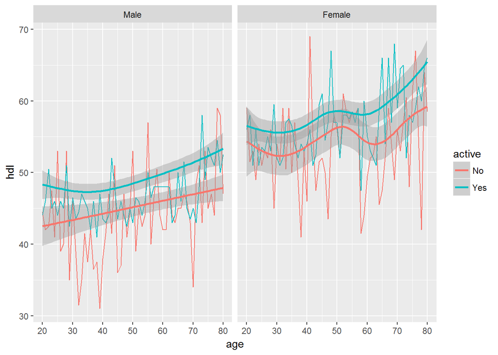

While the smoother indicates that on average, active individuals have higher hdls than inactive individuals, this finding is most clearly established in females aged 65-75. Wild variations in hdl by age indicates that age, gender and activity are weak predictors of hdl.

Our final few plots focus on individuals aged 75-80. There are a large number of active individuals in this age range in our data set, so let us get a picture of their health!

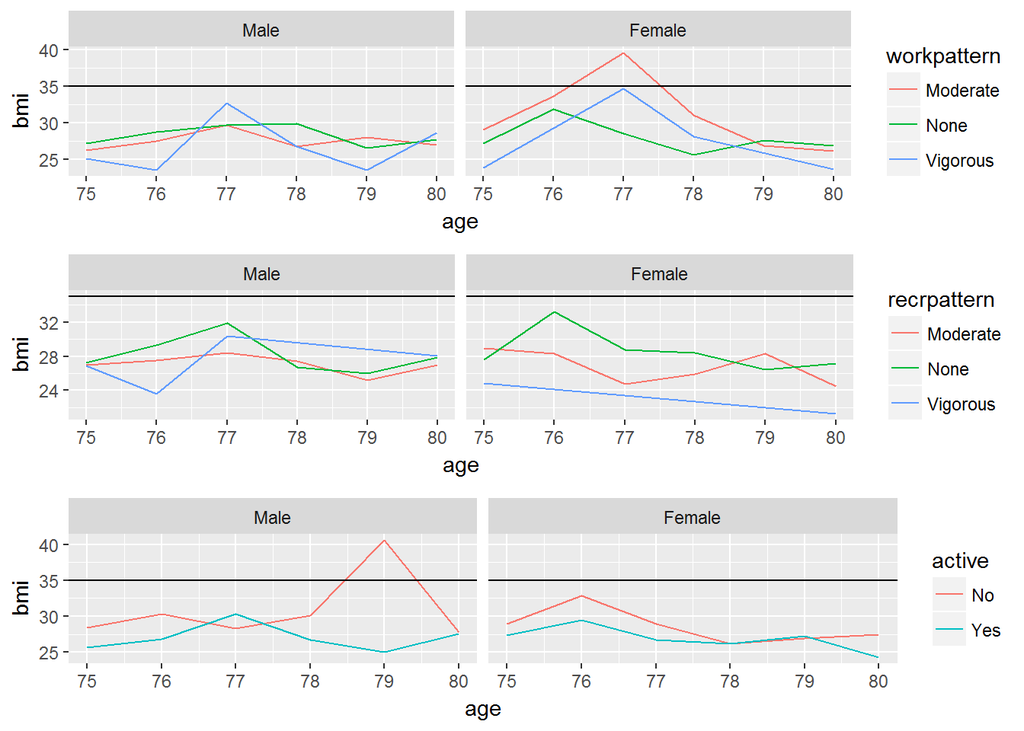

These graphs yield some valuable information:

1. Females aged 77 with moderate work activity on average show high levels of bmi, followed closely by those engaged in vigorous levels of work activity. The former group is one of obese females.
2. Males with any work or recreational activity pattern in their senior years have healthy values of bmi.
3. For senior females undertaking vigorous recreational activity, we see that bmi decreases with age.
4. Senior females with any recreational activity pattern have healthy bmi.
5. Taking any activity into consideration though (work, recreation or walking/biking), we see that senior active females retain healthy bmi levels all through this age profile. Also, in general, staying active correlates to a low bmi for this age group as well.

Finally, let us see how hdl and systolic blood pressure values measure up for senior individuals:

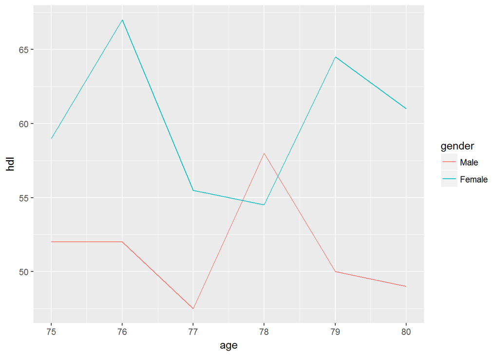

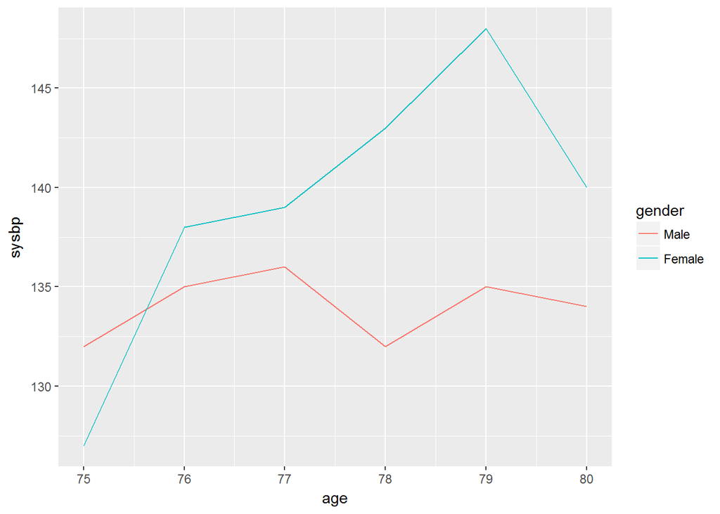

Let us see if a linear model can be built to predict bmi, considering hdl, activity, age and marital status.

```
##
## Call:
## lm(formula = bmi ~ gender + hdl + active + age + marstat, data = activitydf)
##
## Coefficients:
##            (Intercept)            genderFemale                     hdl
##               34.08312                 1.70534                -0.12247
##              activeYes                     age          marstatWidowed
##               -0.94743                 0.02438                -0.34871
##        marstatDivorced        marstatSeparated    marstatNever Married
##                0.25552                 0.41757                -0.35741
## marstatLiving Together
##               -0.84881
```

```
##
## Call:
## lm(formula = bmi ~ gender + hdl + active + age + marstat, data = activitydf)
##
## Residuals:
##     Min      1Q  Median      3Q     Max
## -16.310  -4.100  -0.792   3.185  35.317
##
## Coefficients:
##                         Estimate Std. Error t value Pr(>|t|)
## (Intercept)            34.083123   0.450308  75.688  < 2e-16 ***
## genderFemale            1.705337   0.180886   9.428  < 2e-16 ***
## hdl                    -0.122471   0.005456 -22.448  < 2e-16 ***
## activeYes              -0.947431   0.198320  -4.777 1.83e-06 ***
## age                     0.024378   0.005939   4.105 4.12e-05 ***
## marstatWidowed         -0.348715   0.344630  -1.012  0.31166
## marstatDivorced         0.255517   0.282998   0.903  0.36663
## marstatSeparated        0.417568   0.485437   0.860  0.38973
## marstatNever Married   -0.357414   0.260094  -1.374  0.16945
## marstatLiving Together -0.848814   0.328670  -2.583  0.00984 **
## ---
## Signif. codes:  0 '***' 0.001 '**' 0.01 '*' 0.05 '.' 0.1 ' ' 1
##
## Residual standard error: 5.944 on 4905 degrees of freedom
## Multiple R-squared:  0.1104, Adjusted R-squared:  0.1087
## F-statistic: 67.61 on 9 and 4905 DF,  p-value: < 2.2e-16
```

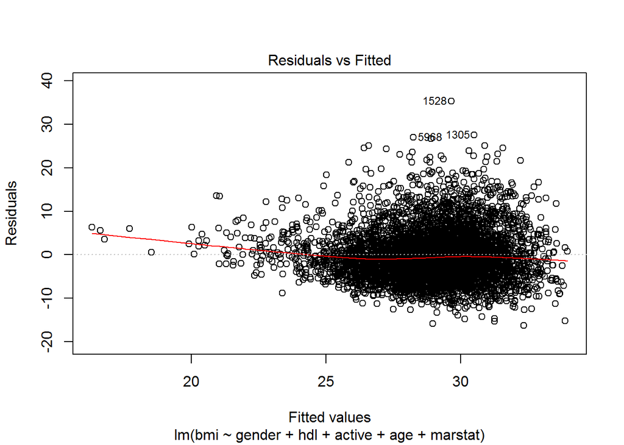

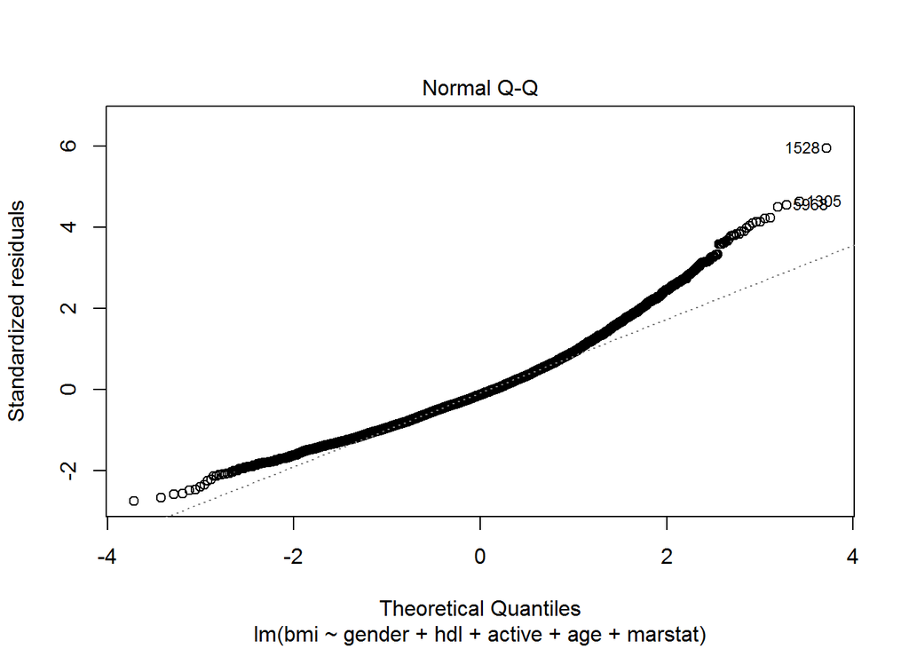

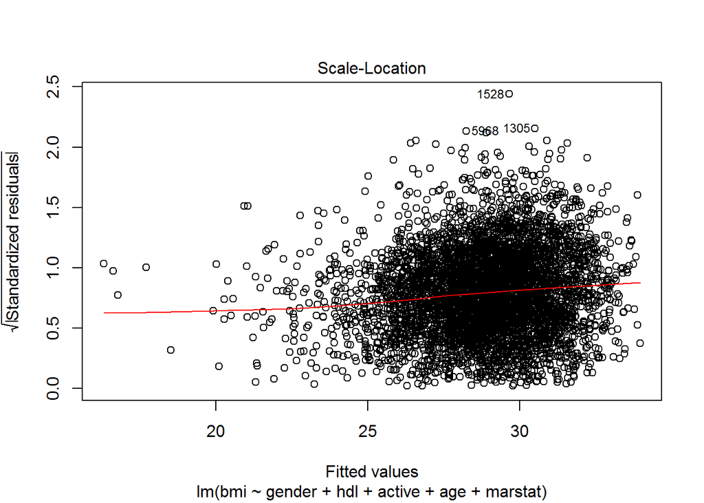

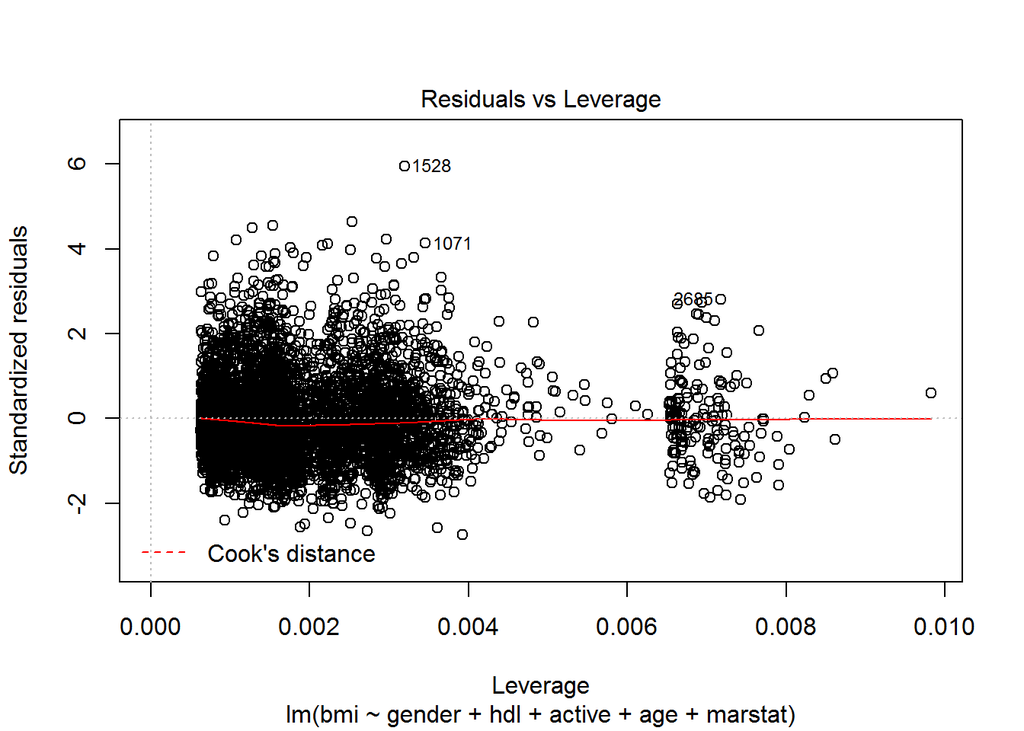

We see from the above model that gender, hdl, activity and age are the most significant predictors of bmi, followed by marital status. However, the model explains only 10.87 % of the variation in bmi. The residual plot shows a flattish red line (except for low values of bmi) indicating the linear model with the selected variables is a reasonable one. The Q-Q plot confirms this finding except for very low and very large quantiles. The fitted values plot shows a significant number of outliers on either side of 1.0. Finally, the leverage plot shows that there are no influential outliers beyond Cook’s distance.

# Multivariate Analysis

### Talk about some of the relationships you observed in this part of the investigation. Were there features that strengthened each other in terms of looking at your feature(s) of interest?

Here are some of the specific findings from performing multivariate analysis:

### Were there any interesting or surprising interactions between features?

Three interactions come forth:

1. Marital status shows an interesting impact on bmi levels. Married people (with and without activity) show stable and lower values of bmi compared to other marital groups.
2. Active individuals show on average, higher levels of hdl, a predictor of a healthy heart.
3. Gender is an important factor in hdl and bmi over all.

### OPTIONAL: Did you create any models with your dataset? Discuss the strengths and limitations of your model.

# Final Plots and Summary

### Plot One

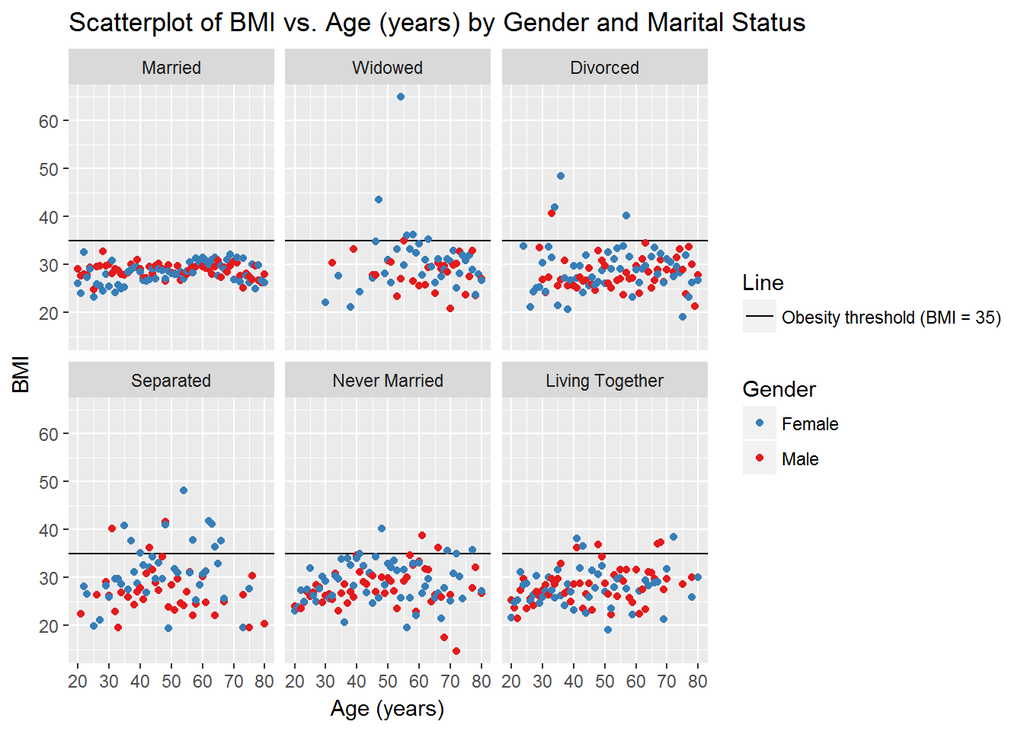

### Description One

The above plot shows the variation in BMI by age and gender, broken down by marital status. I chose this plot as it was immediately interesting to see that married individuals, regardless of age, show strongly stable values of BMI across all ages. This graph led me to investigate activity patterns by gender and marital status, but even there, it became evident that for both, males and females, regardless of activity level, married individuals exhibit on average, the healthiest levels of bmi with very few individuals above the obesity threshold. This points to stability in life being one possible contributing factor. Separated individuals, especially females exhibit high median values of bmi.

### Plot Two

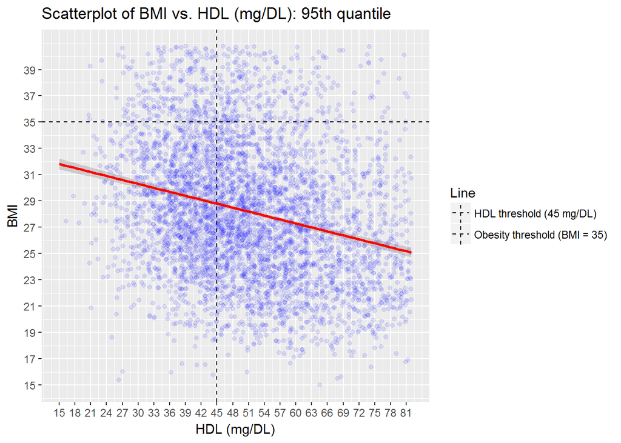

### Description Two

The simple bivariate plot above shows how BMI varies with HDL levels. It is interesting here to see that with increasing HDL levels, we also see generally low BMI levels. Both HDL and BMI are predictors of a healthy heart. We also see here that, ignoring the top 5% HDL values (i.e. possible outliers), there is a high concentration of individuals with HDL between 33 and 70 mg/DL and majority of these individuals have corresponding BMI below the obesity threshold of 35 and HDL greater than 45 mg/DL (average of lower HDL risk threshold for males and females, 40 and 50 mg/DL respectively). This gives us an indication that the population represented in this data set on average, have healthy hearts.

### Plot Three

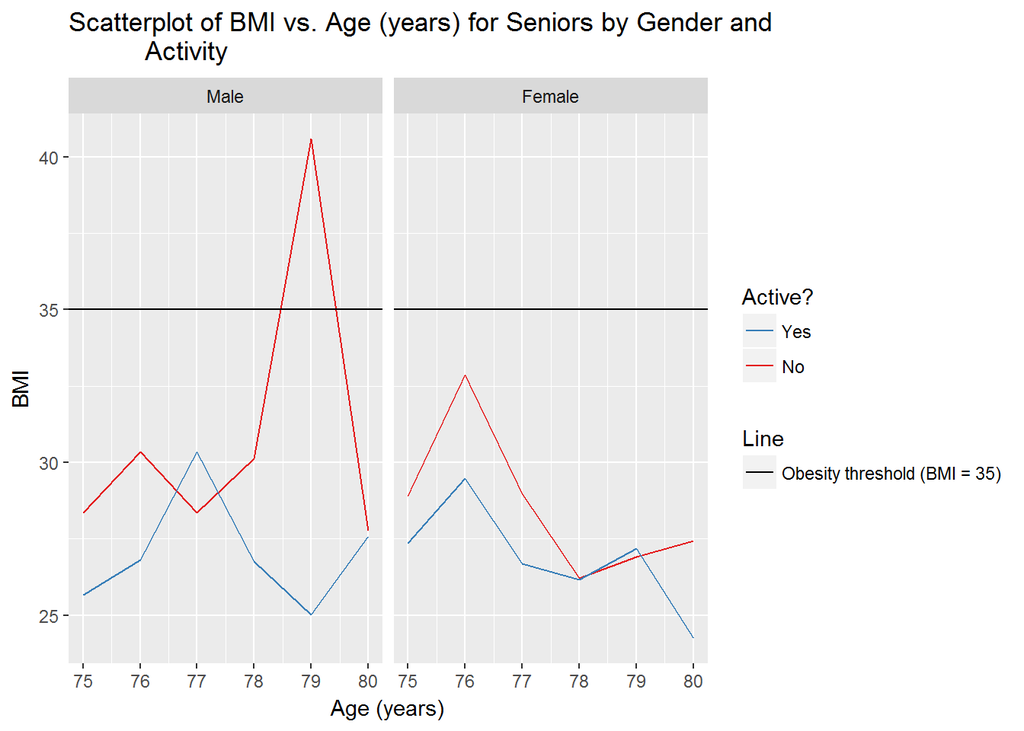

### Description Three

I chose this plot to showcase the bmi profile for senior individuals - range 75- 80 years. It is important to isolate this group for analysis due to their high numbers in the data set. A striking finding here is that senior females, regardless of their activity, have safely healthy bmi levels on average. Of course, active individuals do have lower levels of bmi in general than inactive ones. We also see here that on average, 79 year old inactve males represented in this data set are clearly obese. Their active counterparts sit well below the obesity threshold. This visual reminds us that with some activity in our senior years, we can continue to enjoy healthy hearts and lives.

# Reflection

The NHANES data set 2013, after ignoring missing data, consists of 4915 observations of an individual’s age, height, weight, activity, marital status and other vital metrics to support the study of their health and nutritional status. My objective with this analysis was to explore how these vital metrics correlate to each other, but especially with bmi, considering bmi as the yardstick of a good heart and health. I began by understanding the distribution of data over the different variables, systematically trying to understand how the various health factors correlate with bmi, factoring by age, gender and activity as the main factors. A bmi of 35 was benchmarked as the obesity threshold, as per the survey design. Also, 45 mg/DL was benchmarked as the HDL threshold (taking the average of 40 mg/DL for males, and 50 mg/DL for females). A new dimension called “active” was created to reflect whether or not an individual engaged in any work, recreation, walking or biking activity. As part of the analysis, I isolated the age group of 75-80 year old individuals as this group is oversampled in the data set, but also shows surprisingly good health metrics in the univariate and bivariate analysis. Finally, I tried to follow a logical approach to correlating variables, with specific observations documented at the foot of each plot or set of plots.

Here are some opportunities for further analysis with this data set:

1. Dual axis plots could help show the trend of 2 significant variables (such as hdl, activity, bmi etc.) by age for deeper analysis. I struggled with getting this to work.
2. Work activity, recreational activity, walking and biking should be quantified. This could be done in terms of calories expended or simply minutes/hours per week. This way, it would be possible to perform a more granular analysis of variation in bmi with activity.
3. Likewise, sedentary minutes must be more rigorously specified. I found that this variable had not only discrete values (part of survey design, presumably), but also wildly varying values reported, which led me to drop this variable from my analysis.
4. Ethnicity information could also be included so that it can be possible to consider an individual’s bill of health in relation to their gene pool.
5. Some nutrition information could also be included, e.g. predominant food groups in diet, vegan, gluten-free etc. that would again allow for deeper analysis.
6. There is also scope here for performing more detailed analysis taking marital status or activity levels or blood pressure as the target variable for analysis.
7. Finally, a robust linear model containing more granular variables could be helpful in predicting bmi, and allow for setting benchmark values for different sub-groups in the data set.